# 1000plus collateral flow & perfusion project

Ahmed Khalil

01 November, 2018

### General remarks on methods:

**Reperfusion** is defined as a relative Tmax >4s change of >-50%.  
The Tmax >4s change itself is referred to as **extent of reperfusion**.  
Binarized **infarct growth** is defined as absolute lesion growth (FLAIR D5 - DWI D0) >7mL.  
Surrogates for good collateral flow in this study are:  
* Presence of reperfusion in non-recanalizers  
* The hypoperfusion intensity ration (HIR) at baseline (lower is better), defined according to:  
*Bang, O. Y. et al. (2008) âDeterminants of the distribution and severity of hypoperfusion in patients with ischemic stroke.â, Neurology, 71(22), pp. 1804â“11. doi: 10.1212/01.wnl.0000335929.06390.d3.*  
* The modified ASITN/SIR Collateral Flow Grading System (adapted for DSC-MRI), according to: *Campbell BC V, Christensen S, Tress BM, Churilov L, Desmond PM, Parsons MW, Alan Barber P, Levi CR, Bladin C, Donnan GA, Davis SM (2013) Failure of collateral blood flow is associated with infarct growth in ischemic stroke. J Cereb Blood Flow Metab 33:1168â“1172.*

For visualization (not analysis) purposes, outliers are **not** shown on the boxplots.

**Power analysis:**

Sample size needed to detect minimum R<sup>2</sup> of 0.1 at significance level of 0.05 and power of 0.8 with 11 predictors (including interactions) = 166.0737922. Performed with the R package “pwr”.  
Citation of package:  
*Stephane Champely (2018). pwr: Basic Functions for Power Analysis. R package version 1.2-2. https://CRAN.R-project.org/package=pwr*

### 1. Descriptive statistics

### Data Frame Summary

**allpts**  
**N:** 186

### 2. What is the association between reperfusion and recanalization?

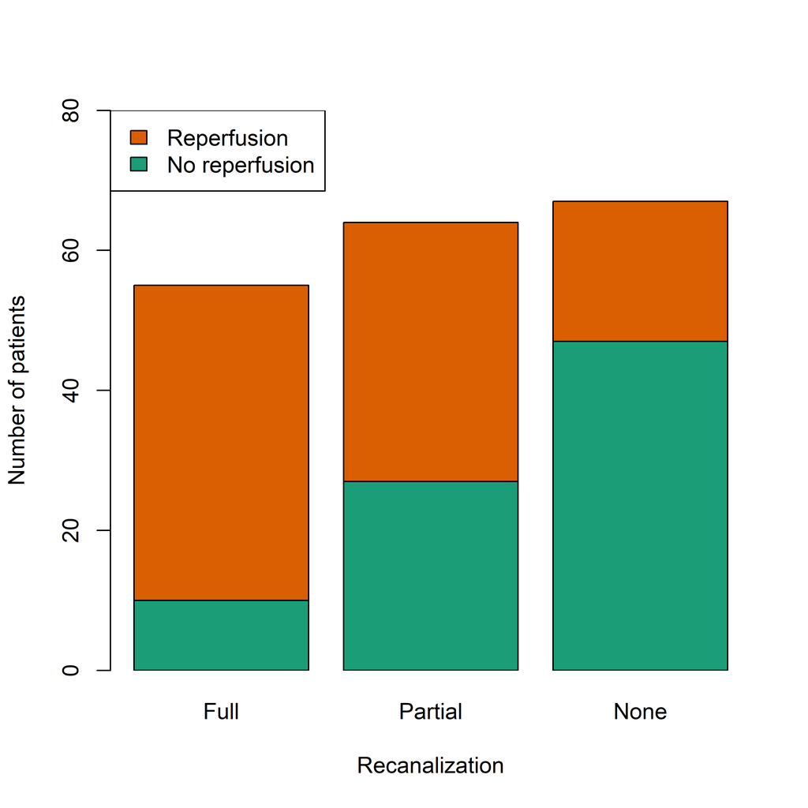

|  | Recanalization Full | Recanalization Partial | Recanalization None |
| --- | --- | --- | --- |
| **Reperfusion** |  |  |  |
| No | 10 | 27 | 47 |
| Yes | 45 | 37 | 20 |

```
##
##  Pearson's Chi-squared test
##
## data:  table(allpts$reperf, allpts$Rekan)
## X-squared = 33.286, df = 2, p-value = 5.917e-08
```

There is a statistically significant difference in the prevalence of reperfusion between the recanalization groups (i.e. reperfusion is associated with recanalization grade).

### 3. Is there a difference in the extent of reperfusion between patients with anterior and posterior circulation strokes?

Models (1) & (2) - in non-recanalizers  
Models (3) & (4) - in recanalizers  
Models (2) & (4) - adjusted for IV tPA  
Models (1) & (3) - not adjusted for IV tPA

**Note: the second iteration of “iv_tPRYes” in the table below refers to the interaction between circulation + IV tPA**

|  | *Dependent variable:* |  |  |  |
| --- | --- | --- | --- | --- |
|  | relTmax_4_change |  | relTmax_4_change |  |
|  | (1) | (2) | (3) | (4) |
| circulationPosterior | 29.520* (16.608) | 11.789 (19.337) |  |  |
|  | t = 1.777 | t = 0.610 |  |  |
|  | p = 0.081 | p = 0.545 |  |  |
| iv_tPRYes |  | -20.471 (14.969) |  |  |
|  |  | t = -1.368 |  |  |
|  |  | p = 0.177 |  |  |
| iv_tPRYes |  | 65.324* (33.648) |  |  |
|  |  | t = 1.941 |  |  |
|  |  | p = 0.057 |  |  |
| circulationPosterior |  |  | 9.670 (8.946) | -4.497 (12.173) |
|  |  |  | t = 1.081 | t = -0.369 |
|  |  |  | p = 0.282 | p = 0.713 |
| iv_tPRYes |  |  |  | -17.255** (7.925) |
|  |  |  |  | t = -2.177 |
|  |  |  |  | p = 0.032 |
| iv_tPRYes |  |  |  | 26.648 (17.689) |
|  |  |  |  | t = 1.506 |
|  |  |  |  | p = 0.135 |
| Constant | -33.737*** (7.392) | -27.465*** (8.692) | -71.274*** (6.148) | -61.023*** (8.142) |
|  | t = -4.564 | t = -3.160 | t = -11.593 | t = -7.494 |
|  | p = 0.00003 | p = 0.003 | p = 0.000 | p = 0.000 |
| Observations | 67 | 67 | 119 | 119 |
| R<sup>2</sup> | 0.059 | 0.118 | 0.013 | 0.068 |
| Adjusted R<sup>2</sup> | 0.045 | 0.075 | 0.005 | 0.044 |
| Residual Std. Error | 56.562 (df = 65) | 55.023 (df = 63) | 27.457 (df = 117) | 27.849 (df = 115) |
| *Note:* | p<0.1; p<0.05; p<0.01 |  |  |  |

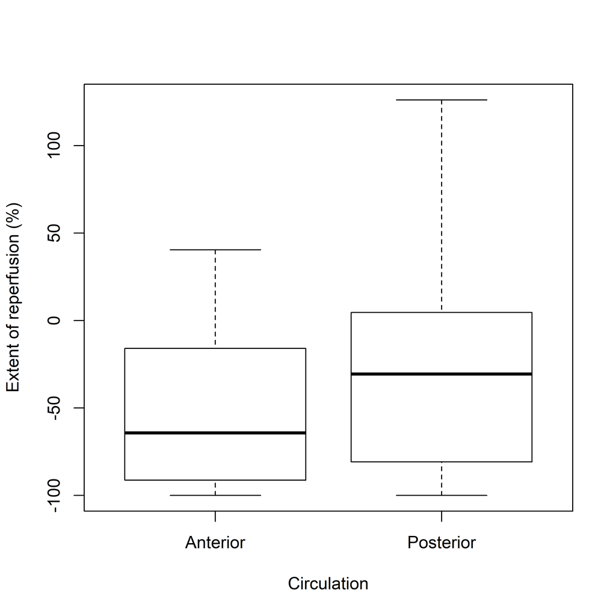

### 4. What factors influence the extent of reperfusion?

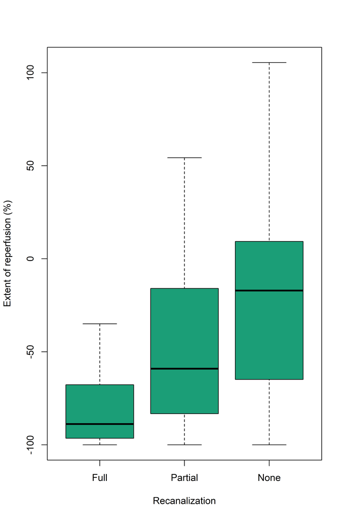

|  | *Dependent variable:* |
| --- | --- |
|  | relTmax_4_change |
| RekanPartial | 25.710*** (6.732) |
|  | t = 3.819 |
|  | p = 0.0002 |
| RekanNone | 46.033*** (9.061) |
|  | t = 5.080 |
|  | p = 0.00000 |
| iv_tPRYes | -12.038 (8.037) |
|  | t = -1.498 |
|  | p = 0.137 |
| TSI | -0.576 (0.710) |
|  | t = -0.811 |
|  | p = 0.419 |
| HIR1 | -18.743 (13.292) |
|  | t = -1.410 |
|  | p = 0.161 |
| higashida_D11 | 37.917** (15.846) |
|  | t = 2.393 |
|  | p = 0.018 |
| higashida_D12 | 40.674*** (14.465) |
|  | t = 2.812 |
|  | p = 0.006 |
| higashida_D13 | 16.863 (15.599) |
|  | t = 1.081 |
|  | p = 0.282 |
| higashida_D14 | 12.135 (14.803) |
|  | t = 0.820 |
|  | p = 0.414 |
| Constant | -88.540*** (15.581) |
|  | t = -5.683 |
|  | p = 0.00000 |
| Observations | 185 |
| R<sup>2</sup> | 0.285 |
| Adjusted R<sup>2</sup> | 0.248 |
| Residual Std. Error | 37.398 (df = 175) |
| *Note:* | p<0.1; p<0.05; p<0.01 |

### 5. Is collateral flow at baseline (HIR) associated with DWI lesion volume and NIHSS at baseline and DWI lesion growth?

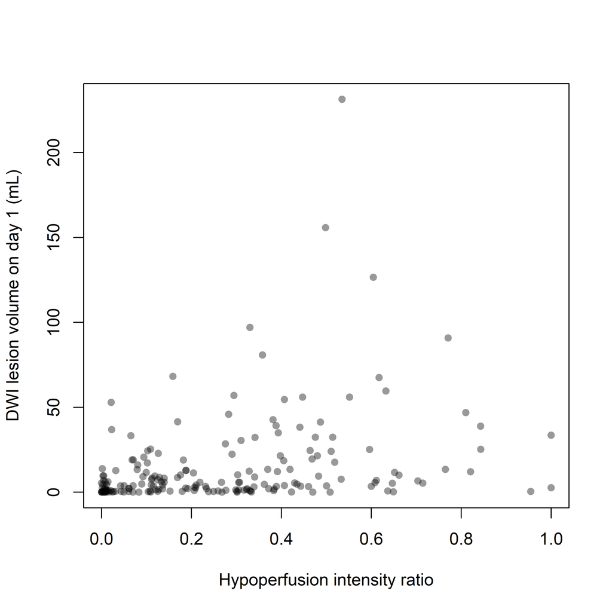

```
##
##  Spearman's rank correlation rho
##
## data:  allpts$HIR1 and allpts$DWIvol_d1
## S = 665110, p-value = 8.947e-08
## alternative hypothesis: true rho is not equal to 0
## sample estimates:
##       rho
## 0.3798217
```

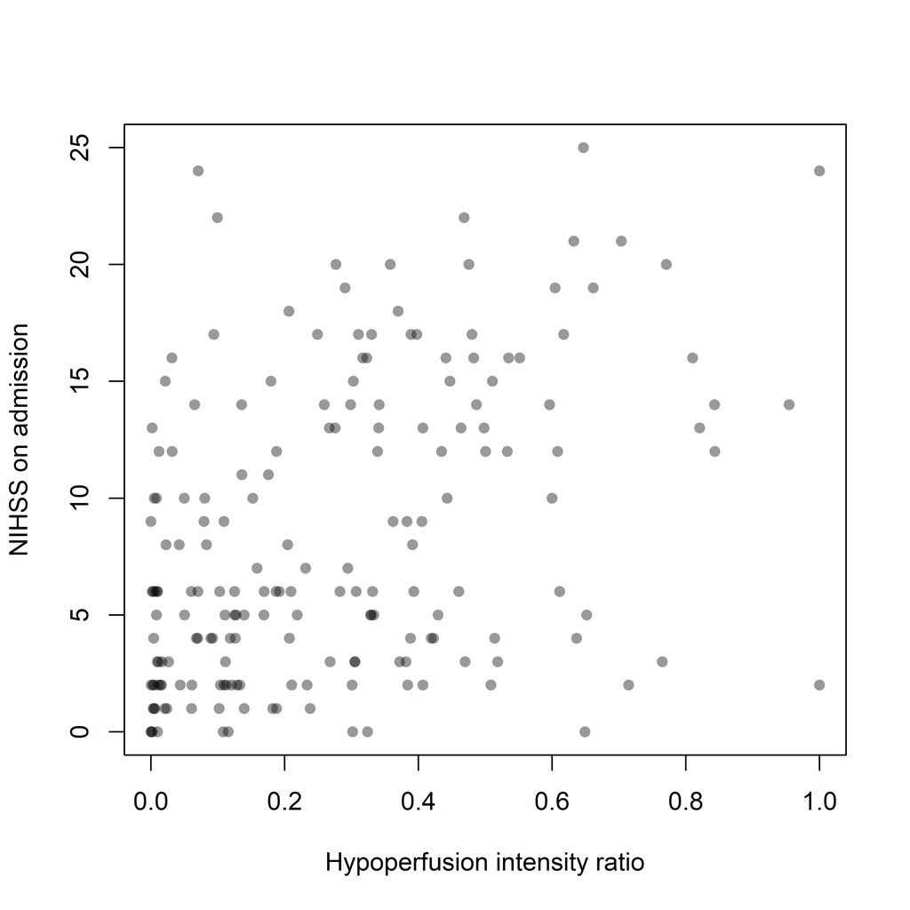

```
##
##  Spearman's rank correlation rho
##
## data:  allpts$HIR1 and allpts$NIHSS_ad
## S = 643250, p-value = 1.518e-08
## alternative hypothesis: true rho is not equal to 0
## sample estimates:
##       rho
## 0.4001989
```

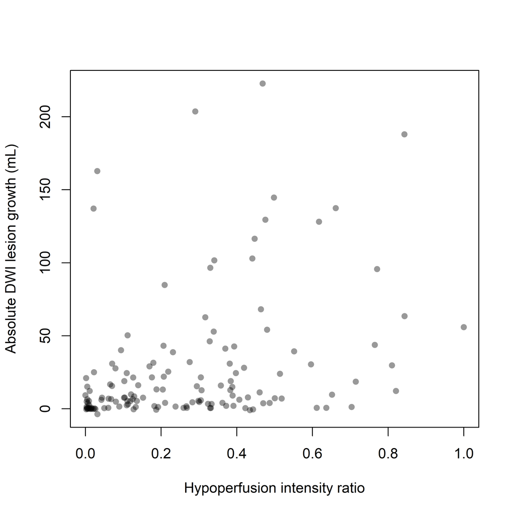

```
##
##  Spearman's rank correlation rho
##
## data:  allpts$HIR1 and allpts$infarct_growth_D5FLAIR
## S = 285800, p-value = 1.964e-06
## alternative hypothesis: true rho is not equal to 0
## sample estimates:
##       rho
## 0.3882452
```

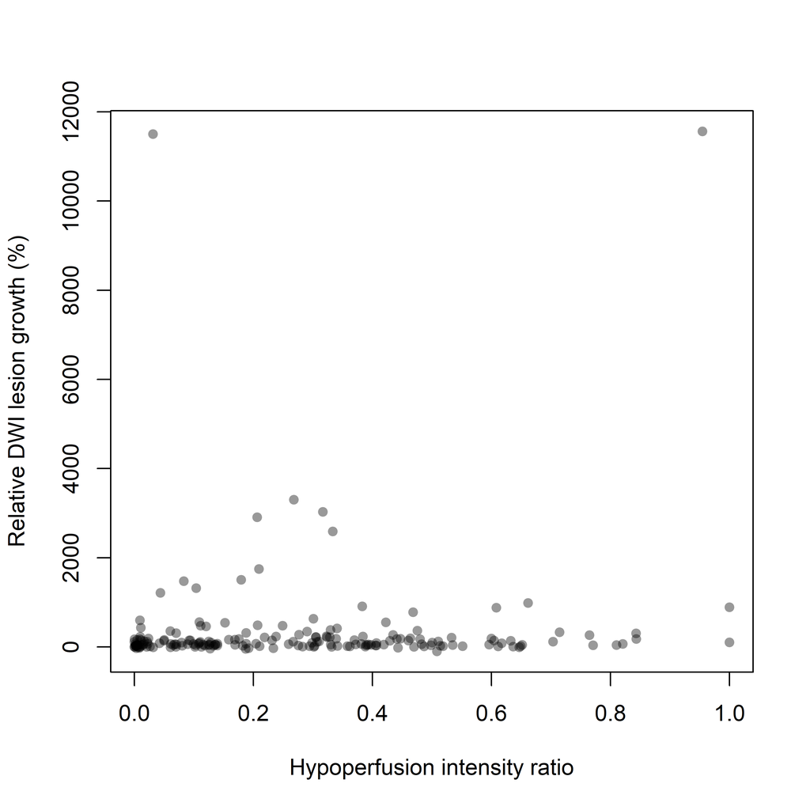

```
##
##  Spearman's rank correlation rho
##
## data:  allpts$HIR1 and allpts$rel_DWIgrowth
## S = 928800, p-value = 0.06836
## alternative hypothesis: true rho is not equal to 0
## sample estimates:
##       rho
## 0.1339397
```

### 6. What factors influence clinical outcome (mRS day90) and infarct growth?

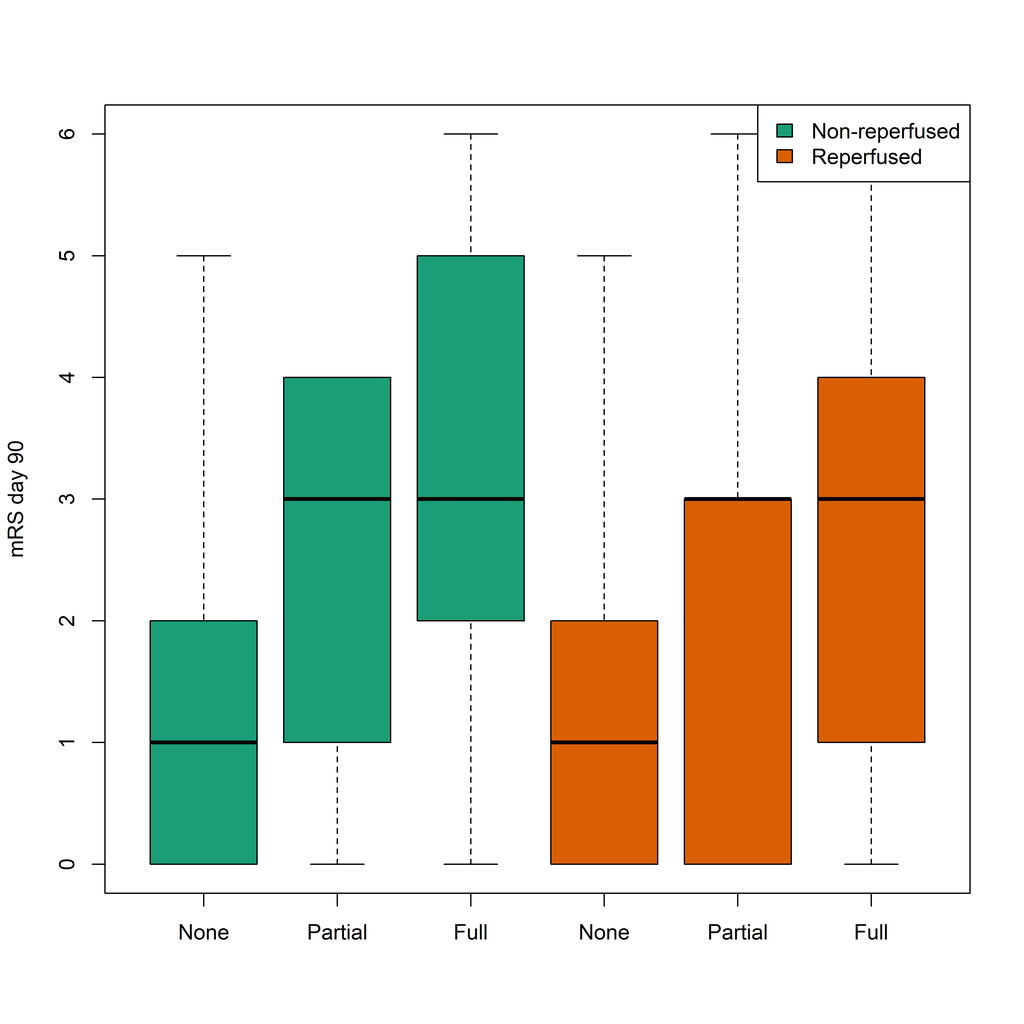

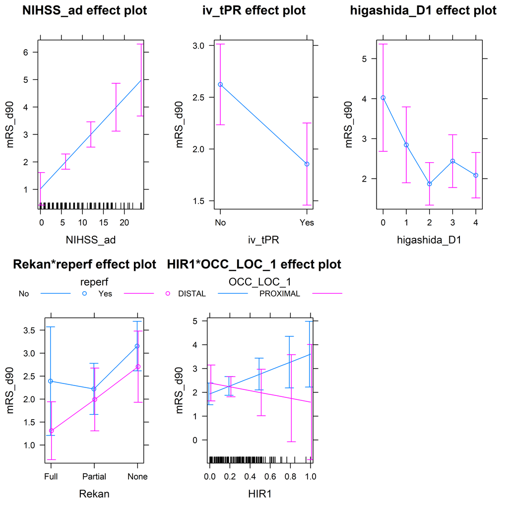

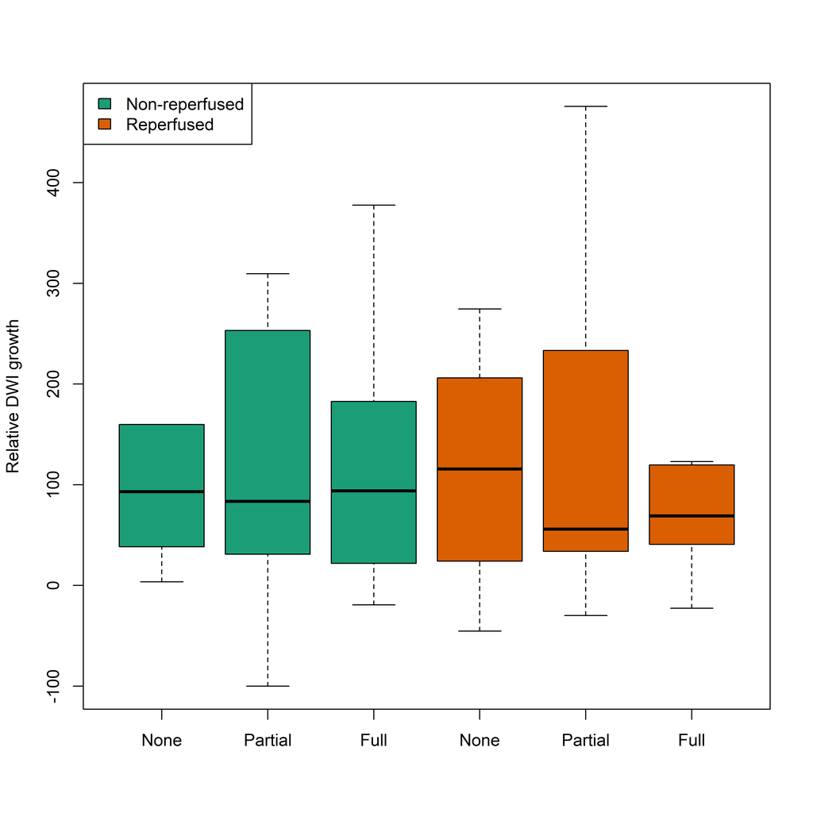

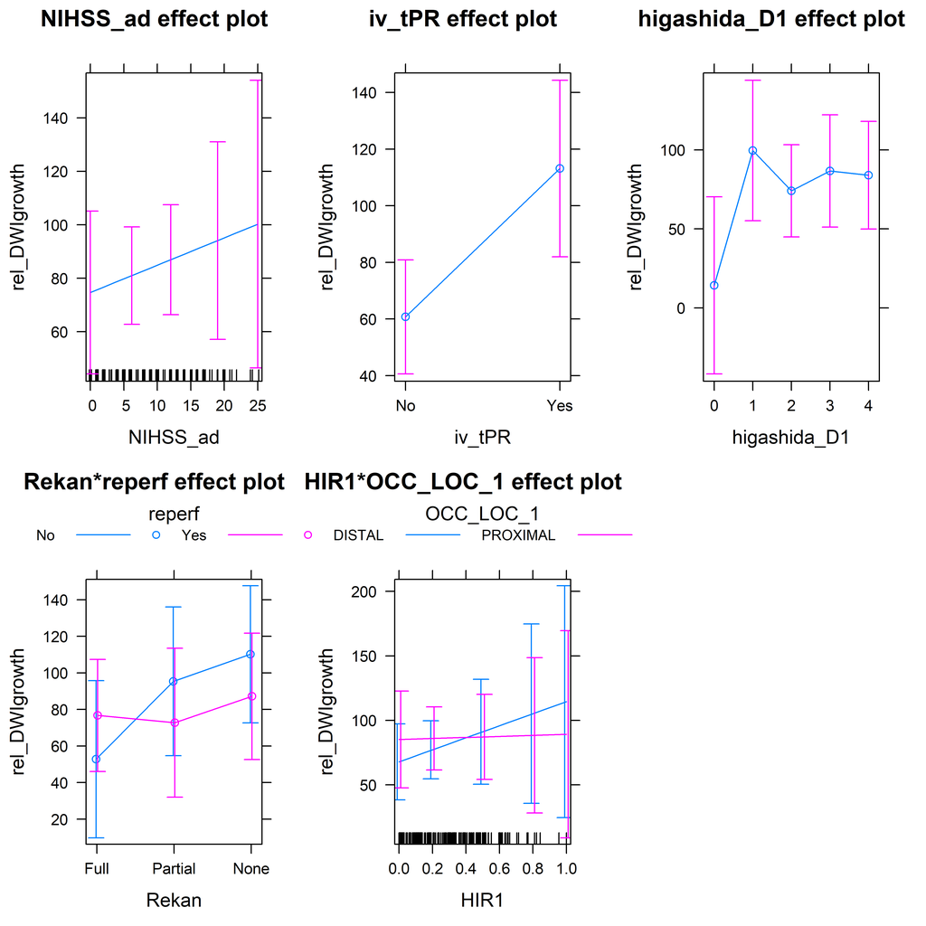

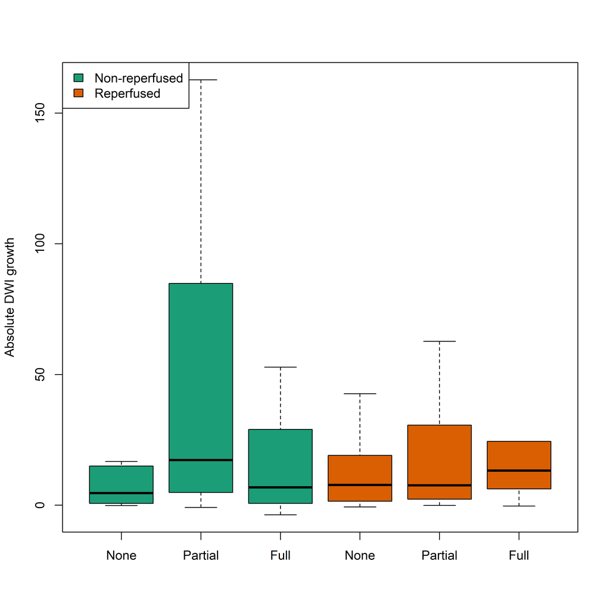

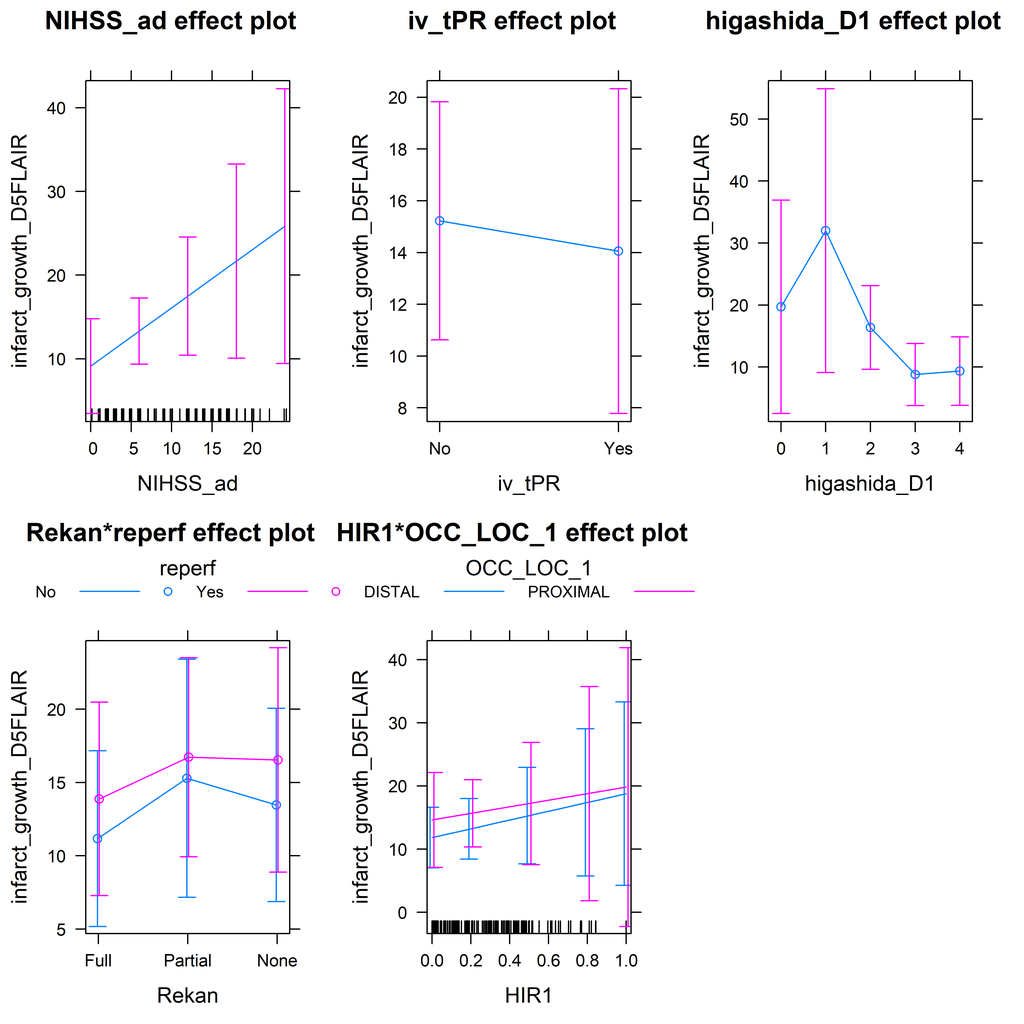

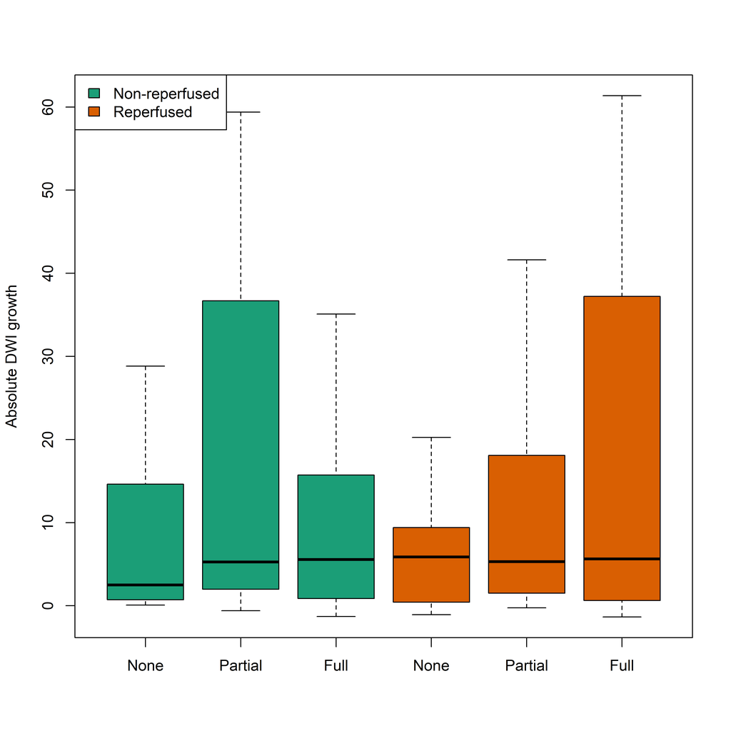

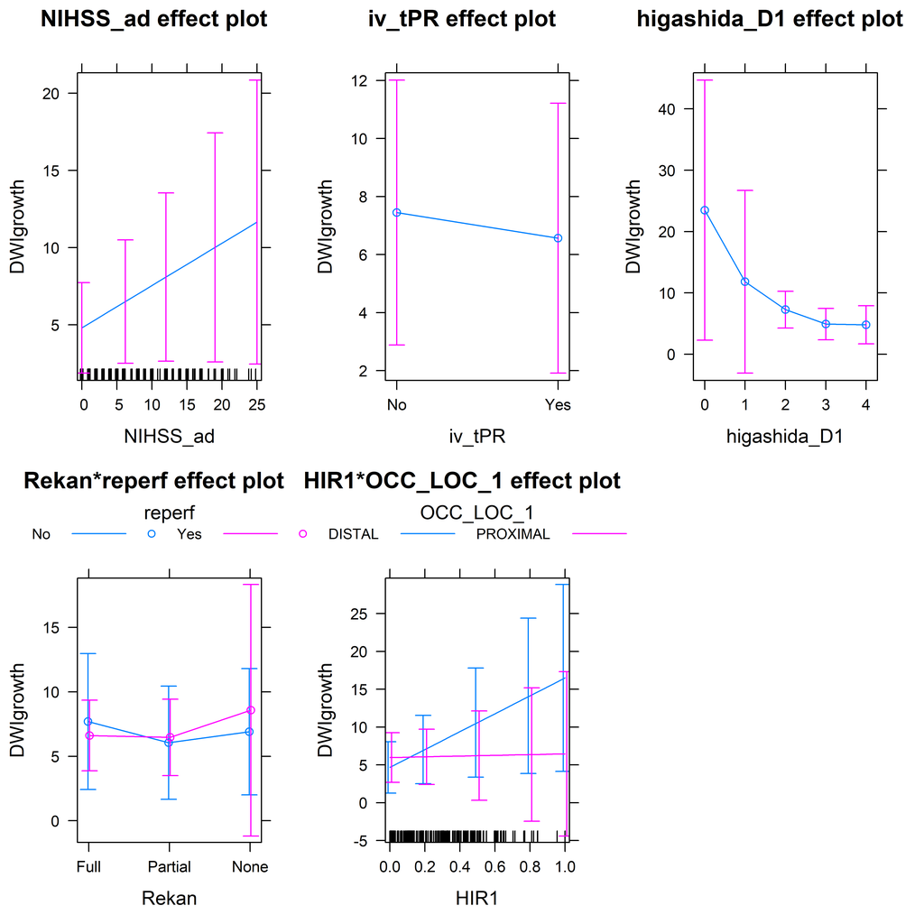

|  | *Dependent variable:* |  |  |  |
| --- | --- | --- | --- | --- |
|  | mRS_d90 | rel_DWIgrowth | infarct_growth_D5FLAIR | DWIgrowth |
|  | (1) | (2) | (3) | (4) |
| RekanPartial | -0.169 (0.659) | 42.605 (29.342) | 4.120 (3.859) | -1.642 (2.310) |
|  | t = -0.256 | t = 1.452 | t = 1.068 | t = -0.711 |
|  | p = 0.799 | p = 0.149 | p = 0.288 | p = 0.479 |
| RekanNone | 0.764 (0.597) | 57.386** (28.270) | 2.304 (3.834) | -0.791 (2.331) |
|  | t = 1.278 | t = 2.030 | t = 0.601 | t = -0.340 |
|  | p = 0.204 | p = 0.044 | p = 0.550 | p = 0.735 |
| reperfYes | -1.078 (0.702) | 23.945 (27.793) | 2.714 (3.668) | -1.077 (2.501) |
|  | t = -1.535 | t = 0.862 | t = 0.740 | t = -0.430 |
|  | p = 0.128 | p = 0.391 | p = 0.461 | p = 0.668 |
| NIHSS_ad | 0.165*** (0.038) | 1.022 (1.544) | 0.697 (0.423) | 0.274* (0.159) |
|  | t = 4.319 | t = 0.662 | t = 1.646 | t = 1.724 |
|  | p = 0.00004 | p = 0.509 | p = 0.103 | p = 0.087 |
| iv_tPRYes | -0.769*** (0.291) | 52.369*** (19.274) | -1.170 (2.831) | -0.879 (1.083) |
|  | t = -2.643 | t = 2.717 | t = -0.413 | t = -0.811 |
|  | p = 0.010 | p = 0.008 | p = 0.681 | p = 0.419 |
| HIR1 | 1.667** (0.792) | 46.683 (53.807) | 6.942 (7.751) | 11.836** (5.562) |
|  | t = 2.104 | t = 0.868 | t = 0.896 | t = 2.128 |
|  | p = 0.038 | p = 0.387 | p = 0.373 | p = 0.035 |
| OCC_LOC_1PROXIMAL | 0.459 (0.401) | 17.334 (20.955) | 2.787 (3.330) | 1.314 (1.457) |
|  | t = 1.145 | t = 0.827 | t = 0.837 | t = 0.902 |
|  | p = 0.255 | p = 0.410 | p = 0.405 | p = 0.369 |
| higashida_D11 | -1.180 (0.767) | 85.296** (35.031) | 12.275 (14.601) | -11.662 (10.378) |
|  | t = -1.538 | t = 2.435 | t = 0.841 | t = -1.124 |
|  | p = 0.127 | p = 0.016 | p = 0.403 | p = 0.263 |
| higashida_D12 | -2.154*** (0.716) | 59.837* (31.889) | -3.350 (9.440) | -16.218 (10.260) |
|  | t = -3.010 | t = 1.876 | t = -0.355 | t = -1.581 |
|  | p = 0.004 | p = 0.063 | p = 0.724 | p = 0.116 |
| higashida_D13 | -1.587** (0.764) | 72.398** (36.584) | -10.924 (8.517) | -18.570* (10.208) |
|  | t = -2.077 | t = 1.979 | t = -1.283 | t = -1.819 |
|  | p = 0.040 | p = 0.050 | p = 0.202 | p = 0.071 |
| higashida_D14 | -1.940** (0.773) | 69.694* (36.565) | -10.379 (8.636) | -18.683* (9.984) |
|  | t = -2.510 | t = 1.906 | t = -1.202 | t = -1.871 |
|  | p = 0.014 | p = 0.059 | p = 0.232 | p = 0.064 |
| RekanPartial:reperfYes | 0.848 (0.799) | -46.613 (34.650) | -1.279 (5.183) | 1.498 (2.718) |
|  | t = 1.061 | t = -1.345 | t = -0.247 | t = 0.551 |
|  | p = 0.291 | p = 0.181 | p = 0.806 | p = 0.583 |
| RekanNone:reperfYes | 0.629 (0.714) | -46.927 (32.739) | 0.358 (4.969) | 2.750 (4.256) |
|  | t = 0.882 | t = -1.433 | t = 0.072 | t = 0.646 |
|  | p = 0.380 | p = 0.154 | p = 0.943 | p = 0.520 |
| HIR1:OCC_LOC_1PROXIMAL | -2.471 (1.786) | -42.678 (62.273) | -1.743 (15.236) | -11.356* (5.793) |
|  | t = -1.383 | t = -0.685 | t = -0.114 | t = -1.960 |
|  | p = 0.169 | p = 0.495 | p = 0.910 | p = 0.052 |
| Constant | 2.841*** (0.916) | -62.159 (48.998) | 8.244 (10.014) | 19.800** (9.883) |
|  | t = 3.103 | t = -1.269 | t = 0.823 | t = 2.003 |
|  | p = 0.003 | p = 0.207 | p = 0.412 | p = 0.047 |
| Observations | 149 | 185 | 141 | 185 |
| R<sup>2</sup> | 0.463 | 0.122 | 0.387 | 0.346 |
| Adjusted R<sup>2</sup> | 0.407 | 0.049 | 0.319 | 0.292 |
| Residual Std. Error | 1.340 (df = 134) | 95.664 (df = 170) | 11.330 (df = 126) | 5.911 (df = 170) |
| *Note:* | p<0.1; p<0.05; p<0.01 |  |  |  |

### 7. Is reperfusion associated with infarct growth?

|  | *Dependent variable:* |
| --- | --- |
|  | infarct_growth |
| RekanPartial | 0.588 (1.095) |
|  | t = 0.537 |
|  | p = 0.592 |
| RekanNone | -0.214 (1.026) |
|  | t = -0.208 |
|  | p = 0.836 |
| reperfYes | 0.486 (0.997) |
|  | t = 0.487 |
|  | p = 0.627 |
| OCC_LOC_1PROXIMAL | -14.161 (882.744) |
|  | t = -0.016 |
|  | p = 0.988 |
| RekanPartial:reperfYes | -1.515 (1.355) |
|  | t = -1.118 |
|  | p = 0.264 |
| RekanNone:reperfYes | 0.134 (1.309) |
|  | t = 0.102 |
|  | p = 0.919 |
| RekanPartial:OCC_LOC_1PROXIMAL | 15.482 (882.744) |
|  | t = 0.018 |
|  | p = 0.987 |
| RekanNone:OCC_LOC_1PROXIMAL | 15.232 (882.744) |
|  | t = 0.017 |
|  | p = 0.987 |
| reperfYes:OCC_LOC_1PROXIMAL | 14.486 (882.744) |
|  | t = 0.016 |
|  | p = 0.987 |
| RekanPartial:reperfYes:OCC_LOC_1PROXIMAL | -14.085 (882.745) |
|  | t = -0.016 |
|  | p = 0.988 |
| RekanNone:reperfYes:OCC_LOC_1PROXIMAL | -14.171 (882.745) |
|  | t = -0.016 |
|  | p = 0.988 |
| Constant | -0.405 (0.913) |
|  | t = -0.444 |
|  | p = 0.657 |
| Observations | 141 |
| Log Likelihood | -89.630 |
| Akaike Inf. Crit. | 203.261 |
| Residual Deviance | 179.261 (df = 129) |
| Null Deviance | 194.267 (df = 140) |
| *Note:* | p<0.1; p<0.05; p<0.01 |

### 8. Model comparisons

|  | *Dependent variable:* |  |  |  |  |
| --- | --- | --- | --- | --- | --- |
|  | mRS_d90 |  |  |  |  |
|  | (1) | (2) | (3) | (4) | (5) |
| NIHSS_ad | 0.179*** (0.028) | 0.178*** (0.025) | 0.168*** (0.029) | 0.149*** (0.031) | 0.190*** (0.031) |
|  | t = 6.363 | t = 7.202 | t = 5.756 | t = 4.885 | t = 6.074 |
|  | p = 0.000 | p = 0.000 | p = 0.00000 | p = 0.00001 | p = 0.000 |
| iv_tPRYes | -0.778*** (0.285) | -0.597** (0.271) | -0.802*** (0.282) | -0.906*** (0.285) | -0.808*** (0.308) |
|  | t = -2.730 | t = -2.204 | t = -2.849 | t = -3.177 | t = -2.628 |
|  | p = 0.008 | p = 0.030 | p = 0.006 | p = 0.002 | p = 0.010 |
| RekanPartial |  | -0.287 (0.666) |  |  |  |
|  |  | t = -0.431 |  |  |  |
|  |  | p = 0.668 |  |  |  |
| RekanNone |  | 0.745 (0.616) |  |  |  |
|  |  | t = 1.210 |  |  |  |
|  |  | p = 0.229 |  |  |  |
| reperfYes |  | -1.006 (0.612) |  |  |  |
|  |  | t = -1.644 |  |  |  |
|  |  | p = 0.103 |  |  |  |
| RekanPartial:reperfYes |  | 0.720 (0.766) |  |  |  |
|  |  | t = 0.939 |  |  |  |
|  |  | p = 0.350 |  |  |  |
| RekanNone:reperfYes |  | 0.688 (0.751) |  |  |  |
|  |  | t = 0.916 |  |  |  |
|  |  | p = 0.362 |  |  |  |
| HIR1 |  |  | 0.781 (0.650) |  |  |
|  |  |  | t = 1.201 |  |  |
|  |  |  | p = 0.232 |  |  |
| higashida_D11 |  |  |  | -1.324 (0.823) |  |
|  |  |  |  | t = -1.607 |  |
|  |  |  |  | p = 0.111 |  |
| higashida_D12 |  |  |  | -2.086*** (0.793) |  |
|  |  |  |  | t = -2.631 |  |
|  |  |  |  | p = 0.010 |  |
| higashida_D13 |  |  |  | -2.121** (0.833) |  |
|  |  |  |  | t = -2.547 |  |
|  |  |  |  | p = 0.012 |  |
| higashida_D14 |  |  |  | -2.442*** (0.840) |  |
|  |  |  |  | t = -2.907 |  |
|  |  |  |  | p = 0.005 |  |
| higashida_change-2 |  |  |  |  | 3.877*** (0.520) |
|  |  |  |  |  | t = 7.451 |
|  |  |  |  |  | p = 0.000 |
| higashida_change-1 |  |  |  |  | 3.683*** (0.436) |
|  |  |  |  |  | t = 8.458 |
|  |  |  |  |  | p = 0.000 |
| higashida_change0 |  |  |  |  | 3.655*** (0.274) |
|  |  |  |  |  | t = 13.361 |
|  |  |  |  |  | p = 0.000 |
| higashida_change1 |  |  |  |  | 3.576*** (0.471) |
|  |  |  |  |  | t = 7.599 |
|  |  |  |  |  | p = 0.000 |
| higashida_change2 |  |  |  |  | 3.100*** (0.532) |
|  |  |  |  |  | t = 5.830 |
|  |  |  |  |  | p = 0.00000 |
| higashida_change3 |  |  |  |  | 1.640 (2.711) |
|  |  |  |  |  | t = 0.605 |
|  |  |  |  |  | p = 0.547 |
| higashida_change4 |  |  |  |  | 4.284*** (0.648) |
|  |  |  |  |  | t = 6.615 |
|  |  |  |  |  | p = 0.000 |
| Constant | 1.187*** (0.269) | 1.257** (0.564) | 1.077*** (0.284) | 3.510*** (0.893) | -2.474*** (0.407) |
|  | t = 4.412 | t = 2.227 | t = 3.790 | t = 3.932 | t = -6.074 |
|  | p = 0.00002 | p = 0.028 | p = 0.0003 | p = 0.0002 | p = 0.000 |
| Observations | 149 | 149 | 149 | 149 | 147 |
| R<sup>2</sup> | 0.276 | 0.390 | 0.282 | 0.320 | 0.329 |
| Adjusted R<sup>2</sup> | 0.266 | 0.360 | 0.267 | 0.291 | 0.284 |
| Residual Std. Error | 1.549 (df = 146) | 1.461 (df = 141) | 1.551 (df = 145) | 1.578 (df = 142) | 1.520 (df = 137) |
| *Note:* | p<0.1; p<0.05; p<0.01 |  |  |  |  |

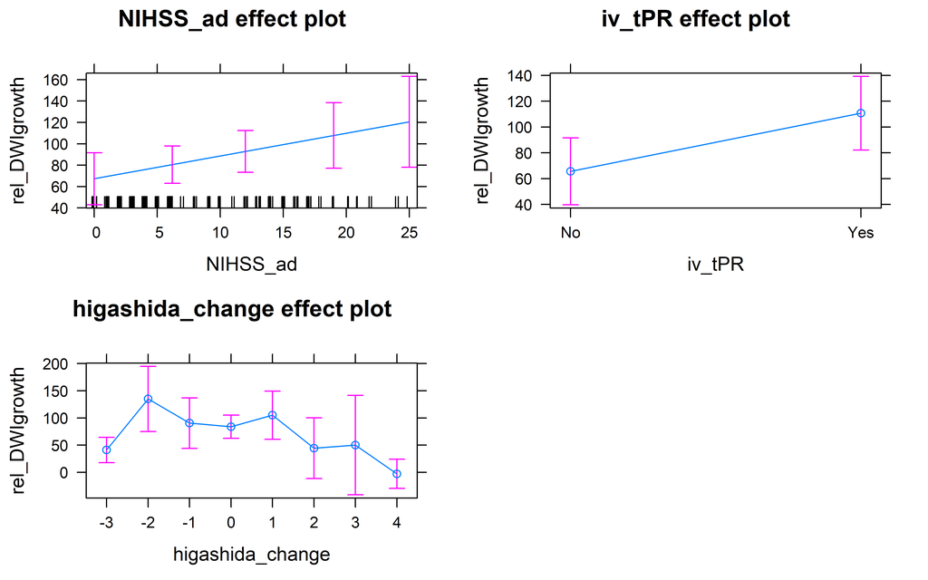

|  | *Dependent variable:* |  |  |  |  |
| --- | --- | --- | --- | --- | --- |
|  | rel_DWIgrowth |  |  |  |  |
|  | (1) | (2) | (3) | (4) | (5) |
| NIHSS_ad | 1.555 (1.129) | 1.586 (1.175) | 0.957 (1.424) | 1.101 (1.294) | 2.132* (1.141) |
|  | t = 1.377 | t = 1.350 | t = 0.672 | t = 0.850 | t = 1.870 |
|  | p = 0.171 | p = 0.179 | p = 0.503 | p = 0.397 | p = 0.064 |
| iv_tPRYes | 40.002** (15.526) | 49.273*** (17.061) | 39.593** (15.382) | 40.940** (16.437) | 45.070** (21.473) |
|  | t = 2.576 | t = 2.888 | t = 2.574 | t = 2.491 | t = 2.099 |
|  | p = 0.011 | p = 0.005 | p = 0.011 | p = 0.014 | p = 0.038 |
| RekanPartial |  | 43.811 (30.030) |  |  |  |
|  |  | t = 1.459 |  |  |  |
|  |  | p = 0.147 |  |  |  |
| RekanNone |  | 56.902** (27.655) |  |  |  |
|  |  | t = 2.058 |  |  |  |
|  |  | p = 0.042 |  |  |  |
| reperfYes |  | 28.448 (24.837) |  |  |  |
|  |  | t = 1.145 |  |  |  |
|  |  | p = 0.254 |  |  |  |
| RekanPartial:reperfYes |  | -51.909 (34.973) |  |  |  |
|  |  | t = -1.484 |  |  |  |
|  |  | p = 0.140 |  |  |  |
| RekanNone:reperfYes |  | -58.328* (32.727) |  |  |  |
|  |  | t = -1.782 |  |  |  |
|  |  | p = 0.077 |  |  |  |
| HIR1 |  |  | 33.612 (37.371) |  |  |
|  |  |  | t = 0.899 |  |  |
|  |  |  | p = 0.370 |  |  |
| higashida_D11 |  |  |  | 81.067*** (22.992) |  |
|  |  |  |  | t = 3.526 |  |
|  |  |  |  | p = 0.001 |  |
| higashida_D12 |  |  |  | 55.241*** (20.574) |  |
|  |  |  |  | t = 2.685 |  |
|  |  |  |  | p = 0.008 |  |
| higashida_D13 |  |  |  | 61.508** (24.287) |  |
|  |  |  |  | t = 2.533 |  |
|  |  |  |  | p = 0.013 |  |
| higashida_D14 |  |  |  | 50.334** (22.498) |  |
|  |  |  |  | t = 2.237 |  |
|  |  |  |  | p = 0.027 |  |
| higashida_change-2 |  |  |  |  | 93.855*** (31.316) |
|  |  |  |  |  | t = 2.997 |
|  |  |  |  |  | p = 0.004 |
| higashida_change-1 |  |  |  |  | 49.393** (24.659) |
|  |  |  |  |  | t = 2.003 |
|  |  |  |  |  | p = 0.047 |
| higashida_change0 |  |  |  |  | 42.744*** (13.908) |
|  |  |  |  |  | t = 3.073 |
|  |  |  |  |  | p = 0.003 |
| higashida_change1 |  |  |  |  | 64.015** (28.457) |
|  |  |  |  |  | t = 2.250 |
|  |  |  |  |  | p = 0.026 |
| higashida_change2 |  |  |  |  | 3.386 (36.233) |
|  |  |  |  |  | t = 0.093 |
|  |  |  |  |  | p = 0.926 |
| higashida_change3 |  |  |  |  | 8.891 (46.079) |
|  |  |  |  |  | t = 0.193 |
|  |  |  |  |  | p = 0.848 |
| higashida_change4 |  |  |  |  | -43.969** (20.757) |
|  |  |  |  |  | t = -2.118 |
|  |  |  |  |  | p = 0.036 |
| Constant | 53.264*** (13.166) | 15.819 (24.337) | 49.858*** (13.007) | -1.660 (25.925) | 4.070 (14.827) |
|  | t = 4.046 | t = 0.650 | t = 3.833 | t = -0.064 | t = 0.274 |
|  | p = 0.0001 | p = 0.517 | p = 0.0002 | p = 0.950 | p = 0.785 |
| Observations | 186 | 186 | 186 | 185 | 182 |
| R<sup>2</sup> | 0.071 | 0.096 | 0.076 | 0.092 | 0.119 |
| Adjusted R<sup>2</sup> | 0.061 | 0.061 | 0.061 | 0.061 | 0.073 |
| Residual Std. Error | 90.827 (df = 183) | 93.905 (df = 178) | 91.770 (df = 182) | 90.600 (df = 178) | 92.420 (df = 172) |
| *Note:* | p<0.1; p<0.05; p<0.01 |  |  |  |  |